# Occupation Trends over Time in AYA

Amanda(Tianyi) Liu

13/07/2021

```r
library(tidyverse)
library(haven)
library(ggplot2)
library(scales)
library(kableExtra)
library(knitr)
```

## Pre-processing

### Loading Data

```r
dat <- read_dta("../data/all_data_original_id_1_19.dta")
dat_part_cleaned <- read_dta("../data/R1_R18_partcleaned_incidence_20190913.dta")

colors <- c("#8d96a3", "#edae49", "94bee3", "#5ec0b2", "#9fc96c", "#5ec0b2")
```

### Creating full dataset

```r
# `hivrslt`: 1 2 3 7 8 9
hivrslt_dat <-
  dat_part_cleaned %>%
  select(study_id, round, hivrslt) %>%
  drop_na(hivrslt)

comm_num_dat <-
  dat_part_cleaned %>%
  select(study_id, round, comm_num) %>%
  drop_na(comm_num)

# .y: dat_part_cleaned
# If conflict in data, use data from "all_data_original_id_1_19.dta"

dat_all <-
  dat %>%
  left_join(hivrslt_dat, by = c("study_id" = "study_id", "round" = "round")) %>%
  mutate(hivrslt = ifelse(is.na(hivrslt.x), hivrslt.y, hivrslt.x)) %>%
  select(-hivrslt.x, -hivrslt.y)

dat_all <-
  dat_all %>%
  left_join(comm_num_dat, by = c("study_id" = "study_id", "round" = "round")) %>%
  mutate(comm_num = ifelse(is.na(comm_num.x), comm_num.y, comm_num.x)) %>%
  select(-comm_num.x, -comm_num.y)
```

Check if all requested variables exist

```r
vars <- c("occup1", "occup2", "occupat1", "occupat2", "occs", # outcome
          "female", "ageyrs", "conf_age", "conf_age_flow", # demographics
          "comm_num",
          "radio", "bicycle","car","motorcyc","latrine", # SES
          "electric", "floor", "othfloor", "roof", "walls",
          "everpreg", "pregnow", "livechild", "numchild", # pregnancy
          "evermarr", "currmarr", "polymar", "evermend", # marriage
          "pabuseyr", "ppushyr", "pfistyr", "pkickyr", # domestic violence
          "pweapyr", "patknyr", "pothvyr",
          "vthrsxpy", "pfocsxpy", "othfsxpy", "othpvyrs",# violence
          "hivrslt",# hiv result
          "occupat11", "occupat21", "occup11", "occup21", "occups1", # partner occupation
          "educate", "educyrs", "school", "finsch", "pregsch", # education
          "movesch", "menasch", "harasch", "bullwsch", "paresch",
          "accomsch", "othsch", "spesch", "addtrain")

dat_all %>% select(all_of(vars))
```

```
## # A tibble: 105,060 x 59
##    occup1 occup2 occupat1 occupat2 occs     female ageyrs conf_age conf_age_flow
##     <dbl>  <dbl> <chr>    <chr>    <chr>   <dbl+l>  <dbl>    <dbl>         <dbl>
##  1      6      1 ""       ""       "NULL"  1 [Fem…     16       NA            16
##  2      6      1 ""       ""       "NULL"  1 [Fem…     18       NA            18
##  3      8      3 "NULL"   "NULL"   "STUDE… 1 [Fem…     20       NA            20
##  4      1      3 ""       ""       ""      1 [Fem…     22       NA            22
##  5      8      3 ""       ""       "STUDE… 0 [Mal…     15       NA            15
##  6      8      3 ""       ""       "NULL"  0 [Mal…     16       NA            16
##  7     10      1 ""       ""       "SHOP … 0 [Mal…     17       NA            17
##  8     10      1 ""       ""       "SHOP … 1 [Fem…     23       NA            23
##  9     10      1 ""       ""       "NULL"  1 [Fem…     23       NA            23
## 10     10      1 ""       ""       "NULL"  1 [Fem…     20       NA            20
## # … with 105,050 more rows, and 50 more variables: comm_num <dbl>, radio <dbl>,
## #   bicycle <dbl>, car <dbl>, motorcyc <dbl>, latrine <dbl>, electric <dbl>,
## #   floor <dbl>, othfloor <chr>, roof <dbl>, walls <dbl>, everpreg <dbl+lbl>,
## #   pregnow <dbl+lbl>, livechild <dbl>, numchild <dbl>, evermarr <dbl+lbl>,
## #   currmarr <dbl+lbl>, polymar <dbl>, evermend <dbl+lbl>, pabuseyr <dbl+lbl>,
## #   ppushyr <dbl+lbl>, pfistyr <dbl+lbl>, pkickyr <dbl+lbl>, pweapyr <dbl+lbl>,
## #   patknyr <dbl+lbl>, pothvyr <dbl+lbl>, vthrsxpy <dbl+lbl>,
## #   pfocsxpy <dbl+lbl>, othfsxpy <dbl+lbl>, othpvyrs <chr>, hivrslt <dbl>,
## #   occupat11 <chr>, occupat21 <chr>, occup11 <dbl>, occup21 <dbl>,
## #   occups1 <chr>, educate <dbl+lbl>, educyrs <dbl>, school <dbl+lbl>,
## #   finsch <dbl+lbl>, pregsch <dbl+lbl>, movesch <dbl+lbl>, menasch <dbl+lbl>,
## #   harasch <dbl+lbl>, bullwsch <dbl+lbl>, paresch <dbl+lbl>,
## #   accomsch <dbl+lbl>, othsch <dbl+lbl>, spesch <chr>, addtrain <dbl>
```

```r
# "occupat1", "occupat2", "occs",
# "conf_age", "conf_age_flow", visit
# "livechild", "numchild",
# "othpvyrs", "hivrslt",
# "occup11", "occup21", "occups1",
# "addtrain"
```

### Data Cleaning

**1. Create `age` variable by merging information from `conf_age_flow`, `conf_age`, `ageyrs`**

```r
# Prioritization: `conf_age_flow` -> `conf_age` -> `ageyrs`
dat_all <-
  dat_all %>%
  mutate(age = ifelse(is.na(conf_age_flow), conf_age, conf_age_flow)) %>%
  mutate(age = ifelse(is.na(age), ageyrs, age))
```

##### Filter by age (15-24 year-old respondents) and generate `age groups` variable (15-17, 18-19, 20-24)

```r
dat_all <-
  dat_all %>%
  filter(15 <= age & age <= 24) %>%
  mutate(age_cat = cut(age, breaks = c(14.5, 17.5, 19.5, 24.5), labels = c(1, 2, 3))) %>%
  mutate(age_cat = labelled(age_cat, c("15-17" = 1, "18-19" = 2, "20-24" = 3)))
```

- Generate `visit` variable

```r
dat_all <-
  dat_all %>%
  mutate(visit = str_sub(round, 2, -1)) %>%
  mutate(visit = as.numeric(visit))
```

- Generate `time period` variable (R1-R9 and R10-R19)

```r
dat_all <-
  dat_all %>%
  mutate(period = cut(visit, breaks = c(0.5, 9.5, 19.5), labels = c(1, 2))) %>%
  mutate(period = labelled(period, c("R1-R9" = 1, "R10-R19" = 2)))
```

- Generate `area` variable

```r
comm_fishing <- c(23, 38, 370, 770, 771, 772, 773, 774, 51, 776)
area_fishing <- rep("fishing", length(comm_fishing))

comm_rural <- c(3, 6, 7, 8, 10, 11, 12, 13, 14, 15, 16, 17, 18, 19, 20, 21, 25, 27, 28, 29, 30, 31, 32, 33, 34, 35, 36, 44, 52, 53, 54, 55, 56, 57, 58, 59, 60, 61, 62, 65, 67, 68, 77, 81, 84, 89, 94, 95, 103, 106, 107, 108, 109, 120, 177, 183, 256, 391, 401, 451, 468, 602, 755, 760, 900, 901)
area_rural <- rep("rural", length(comm_rural))

comm_periurban <- c(1, 2, 4, 5, 9, 22, 24, 26, 40, 45, 46, 74, 754)
area_periurban <- rep("periurban", length(comm_periurban))

area <- data.frame("comm_num" = c(comm_fishing, comm_rural, comm_periurban),
                   "area" = c(area_fishing, area_rural, area_periurban))

dat_all <-
  dat_all %>%
  left_join(area)
```

- Categorize occupations for respondents (based on R1-18 part cleaned data)

```r
# labelling occupations
occup_lab <- c("Agriculture for home use/barter" = 1,
               "Agriculture for selling" = 2,
               "Housework in your own home" = 3,
               "Housekeeper (for relative or employer)" = 4,
               "Home brewing" = 5,
               "Government/clerical/teaching" = 6,
               "Fishing" = 7,
               "Student" = 8,
               "Military/police" = 9,
               "Shopkeeper" = 10,
               "Trading/vending" =  11,
               "Bar worker or owner" = 12,
               "Trucker" =  13,
               "Unemployed" = 14,
               "Other" = 15,
               "No additional occupation" = 88,
               "Medical worker (non-government)" = 16,
               "Casual laborer" =  17,
               "Waitress/Waiter/restaurant owner" = 18,
               "Hair dresser/Salon owner" = 19,
               "Construction (brick maker, builder, porter, painter, roofing)" = 20,
               "Mechanic (automobiles, bicycles, electronics)" = 21,
               "Boda Boda" = 22,
               "Client/Sex worker" = 23,
               "Sports betting, Gambling machine, Ludo" = 24,
               "Don't know" = 97,
               "Don't know" = 98,
               "No response" = 99)

dat_all$occup1 <- dat_all$occup1 %>% labelled(occup_lab)
dat_all$occup2 <- dat_all$occup2 %>% labelled(occup_lab)

# categorize occupation
occup1_cat <- dat_part_cleaned %>% select(occup1, occup1_cat) %>% unique() %>% arrange(occup1) %>% drop_na(occup1)
occup2_cat <- occup1_cat %>% rename(occup2 = occup1, occup2_cat = occup1_cat)

occup1_mob <- dat_part_cleaned %>% select(occup1, occup1_mob) %>% unique() %>% arrange(occup1) %>% drop_na(occup1)
occup2_mob <- occup1_mob %>% rename(occup2 = occup1, occup2_mob = occup1_mob)

dat_all <-
  dat_all %>%
  left_join(occup1_cat, by = ("occup1" = "occup1")) %>%
  left_join(occup1_mob, by = ("occup1" = "occup1"))

dat_all <- dat_all %>%
  left_join(occup2_cat, by = ("occup2" = "occup2")) %>%
  left_join(occup2_mob, by = ("occup2" = "occup2"))
```

- Recoding/labelling `hivrslt` variable

```r
# `hivrslt`: 1 2 3 7 8 9
hivrslt_lab <- c("Negative" = 1,
                 "Positive" = 2,
                 "Indeterminate" = 3,
                 "Don’t know/Don’t remember" = 7,
                 "NA" = 8,
                 "No Response" = 9)

dat_all$hivrslt <- dat_all$hivrslt %>% labelled(hivrslt_lab)
```

## Preliminary Analysis

- Visualize general occupation trends
  - Top occupations for each community type

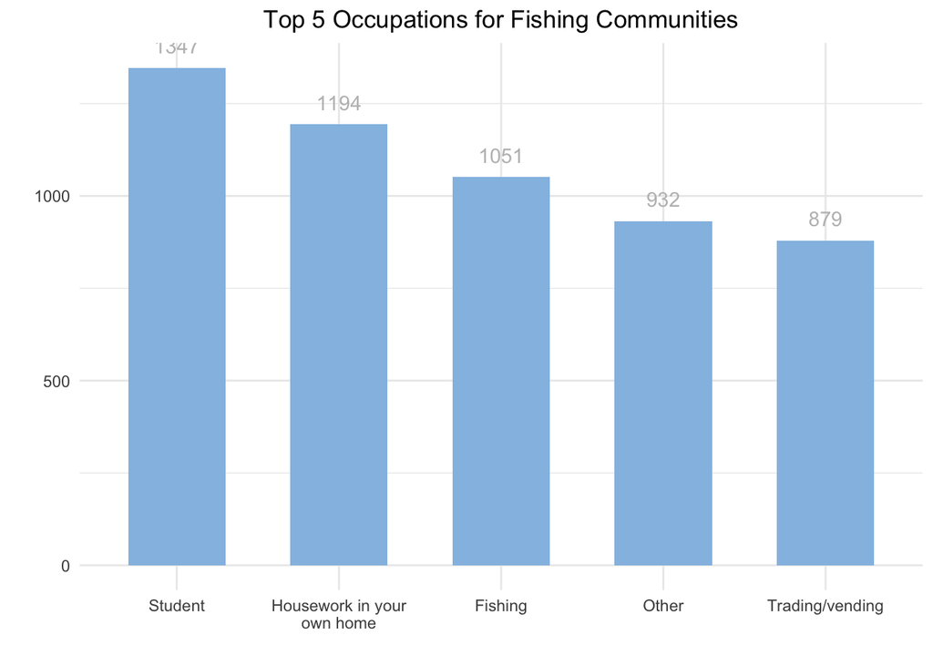

```r
top_occup_area <-
  dat_all %>%
  select (study_id, visit, area, occup1) %>%
  gather(key, occup, -study_id, -visit, -area) %>%
  as_factor() %>%
  mutate(dummy = "yes") %>%
  spread(occup, dummy) %>%
  gather(job, value,  -study_id, -visit, -area, -key) %>%
  drop_na() %>%
  group_by(area, job) %>%
  summarise_at(vars(value), funs(sum(.=="yes")))

top_occup_area %>%
  filter(area == "fishing") %>%
  arrange(desc(value)) %>%
  top_n(n=5) %>%
  ggplot(aes(x=factor(job, unique(job)), y=value)) +
  geom_bar(stat="identity", fill="#94bee3", width=0.6) +
  geom_text(aes(label=value), vjust = -1, color = "grey") +
  scale_x_discrete(labels = wrap_format(20)) +
  labs(x='', y='', title = "Top 5 Occupations for Fishing Communities") +
  theme_minimal() + theme(plot.title = element_text(hjust = 0.5))
```

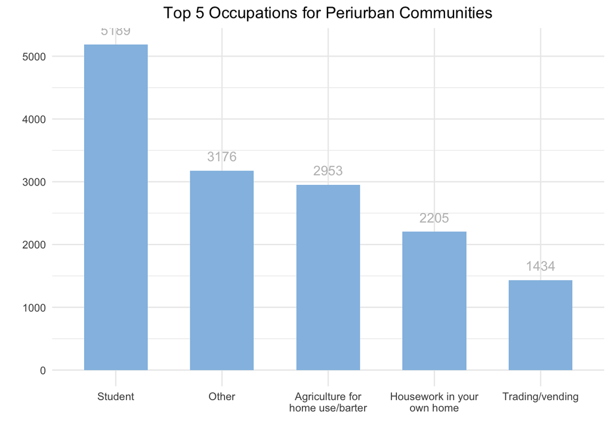

```r
top_occup_area %>%
  filter(area == "periurban") %>%
  arrange(desc(value)) %>%
  top_n(n=5) %>%
  ggplot(aes(x=factor(job, unique(job)), y=value)) +
  geom_bar(stat="identity", fill="#94bee3", width=0.6) +
  geom_text(aes(label=value), vjust = -1, color = "grey") +
  scale_x_discrete(labels = wrap_format(20)) +
  labs(x='', y='', title = "Top 5 Occupations for Periurban Communities") +
  theme_minimal() + theme(plot.title = element_text(hjust = 0.5))
```

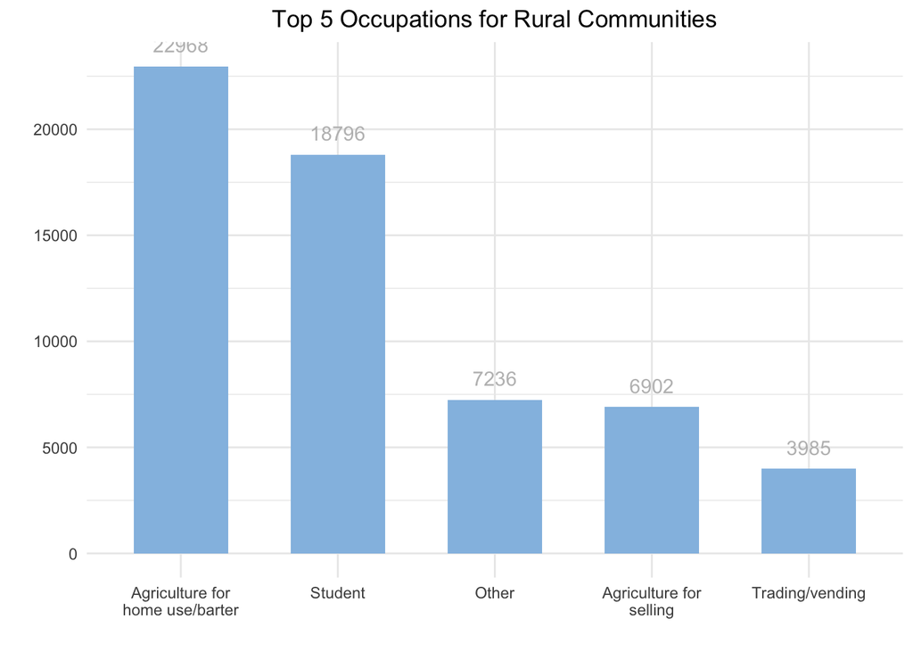

```r
top_occup_area %>%
  filter(area == "rural") %>%
  arrange(desc(value)) %>%
  top_n(n=5) %>%
  ggplot(aes(x=factor(job, unique(job)), y=value, fill)) +
  geom_bar(stat="identity", fill="#94bee3", width=0.6) +
  geom_text(aes(label=value), vjust = -1, color = "grey") +
  scale_x_discrete(labels = wrap_format(20)) +
  labs(x='', y='', title = "Top 5 Occupations for Rural Communities") +
  theme_minimal() + theme(plot.title = element_text(hjust = 0.5))
```

- Top occupations for each gender

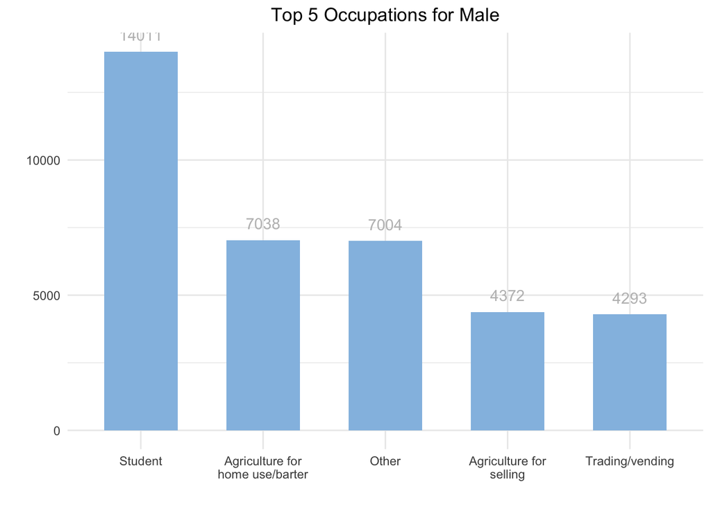

```r
top_occup_gender <-
  dat_all %>%
  select (study_id, visit, female, occup1) %>%
  gather(key, occup, -study_id, -visit, -female) %>%
  as_factor() %>%
  mutate(dummy = "yes") %>%
  spread(occup, dummy) %>%
  gather(job, value,  -study_id, -visit, -female, -key) %>%
  drop_na() %>%
  group_by(female, job) %>%
  summarise_at(vars(value), funs(sum(.=="yes")))

top_occup_gender %>%
  filter(female == "Male") %>%
  arrange(desc(value)) %>%
  top_n(n=5) %>%
  ggplot(aes(x=factor(job, unique(job)), y=value)) +
  geom_bar(stat="identity", fill="#94bee3", width=0.6) +
  geom_text(aes(label=value), vjust = -1, color = "grey") +
  scale_x_discrete(labels = wrap_format(20)) +
  labs(x='', y='', title = "Top 5 Occupations for Male") +
  theme_minimal() + theme(plot.title = element_text(hjust = 0.5))
```

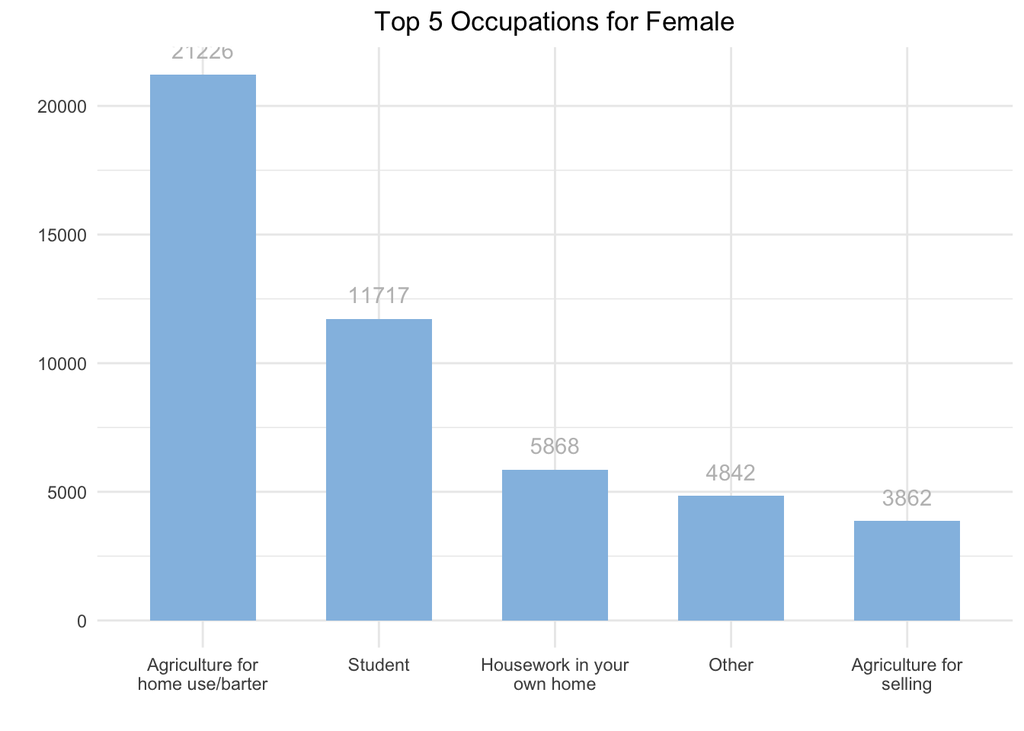

```r
top_occup_gender %>%
  filter(female == "Female") %>%
  arrange(desc(value)) %>%
  top_n(n=5) %>%
  ggplot(aes(x=factor(job, unique(job)), y=value)) +
  geom_bar(stat="identity", fill="#94bee3", width=0.6) +
  geom_text(aes(label=value), vjust = -1, color = "grey") +
  scale_x_discrete(labels = wrap_format(20)) +
  labs(x='', y='', title = "Top 5 Occupations for Female") +
  theme_minimal() +
  theme(plot.title = element_text(hjust = 0.5))
```

- Top occupations for each age group

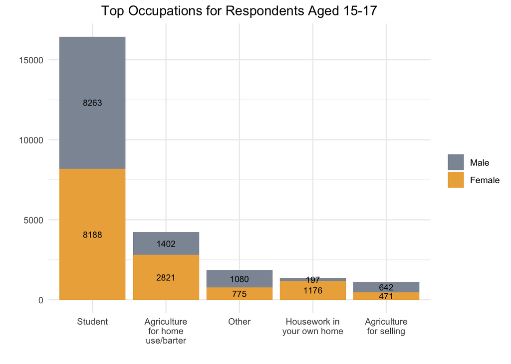

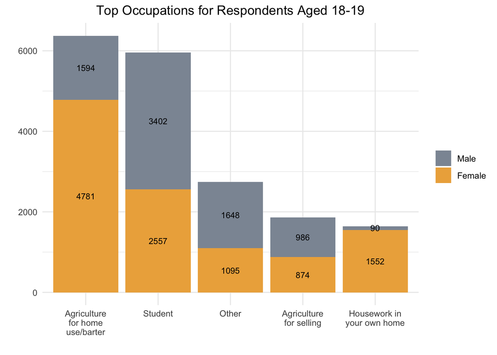

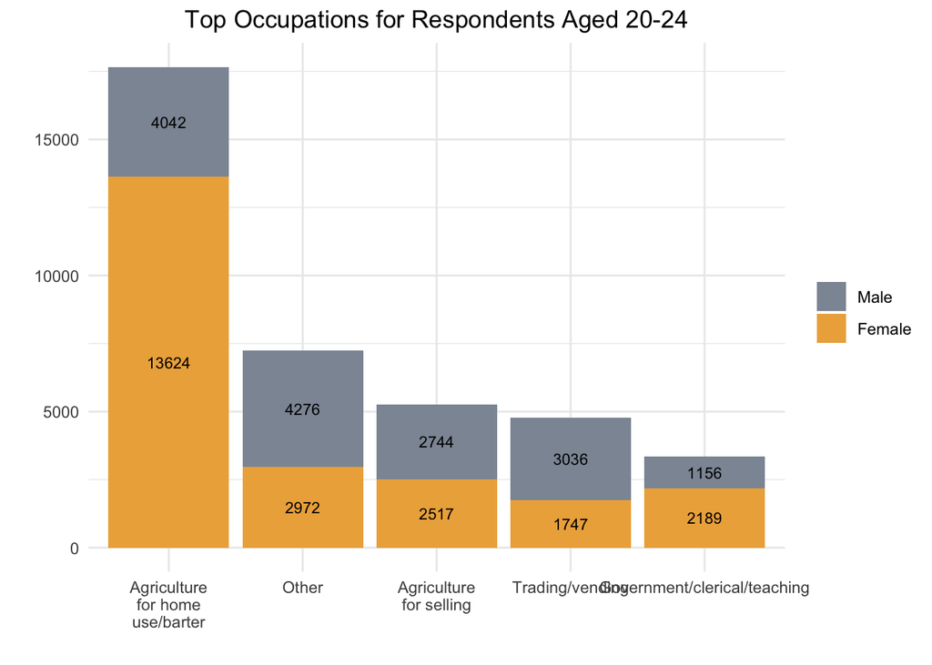

```r
top_occup_agecat <-
  dat_all %>%
  select (study_id, visit, female, age_cat, occup1) %>%
  gather(key, occup, -study_id, -visit, -age_cat, -female) %>%
  as_factor() %>%
  mutate(dummy = "yes") %>%
  spread(occup, dummy) %>%
  gather(job, value,  -study_id, -visit, -age_cat, -key, -female) %>%
  drop_na() %>%
  group_by(age_cat, job, female) %>%
  summarise_at(vars(value), funs(sum(.=="yes"))) %>%
  mutate(frequency = sum(value))

for (i in c("15-17", "18-19", "20-24")){
  p <- top_occup_agecat %>%
    filter(age_cat == i) %>%
    arrange(desc(frequency)) %>%
    head(10) %>%
    ggplot(aes(x = factor(job, unique(job)), y = value, fill = female, label = value)) +
    geom_bar(stat = "identity")+
    geom_text(size = 3, position = position_stack(vjust = 0.5)) +
    scale_fill_manual(values=colors) +
    scale_x_discrete(labels = wrap_format(15)) +
    labs(x='', y='', title = paste("Top Occupations for Respondents Aged", i)) +
    theme_minimal() +
    theme(plot.title = element_text(hjust = 0.5),
          legend.title = element_blank())
  print(p)
}
```

It can be observed from above analysis that the top occupations for AYA include `Student`, `Agriculture for home use/barter`, `Housework in your own home`, `Agriculture for selling`, `Government/clerical/teaching`, `Trading/Vending` and `Other` (in addition to one community-specific occupation `Fishing`). Therefore, following analysis will be mainly focused on these occupations.

- Describe trends over time in AYA occupations
  - Trend by `visit`

```r
# Student 8
# Agriculture for home use/barter 1
# Housework in your own home 3
# Agriculture for selling 2
# Government/clerical/teaching 6
# Trading/Vending 11
# Other 15
# Fishing 7

occup_list <- c("Student",
                "Agriculture for home use/barter",
                "Housework in your own home",
                "Agriculture for selling",
                "Government/clerical/teaching",
                "Trading/vending",
                "Other",
                "Fishing")
```

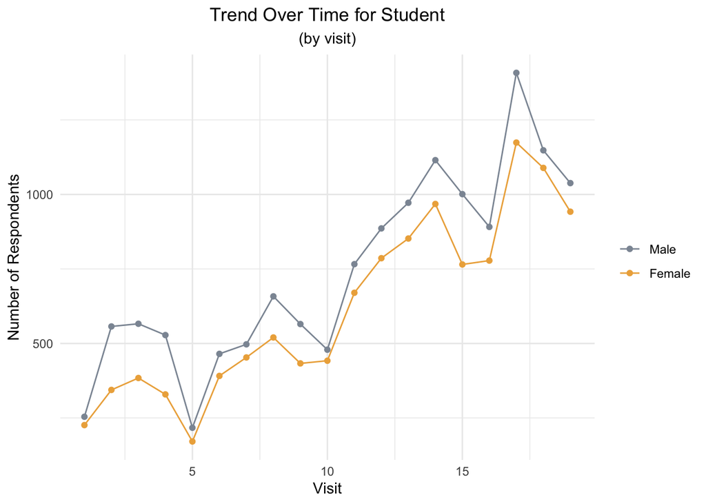

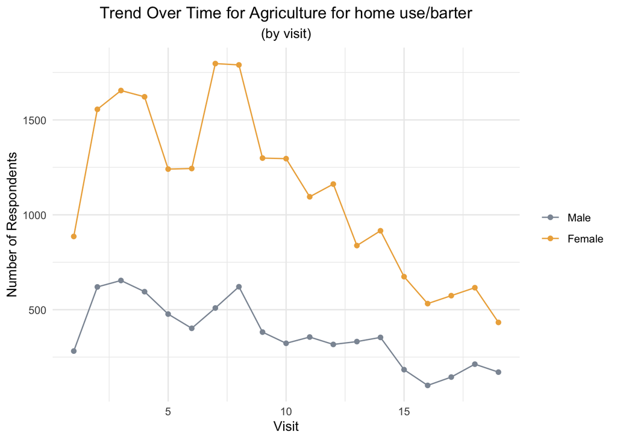

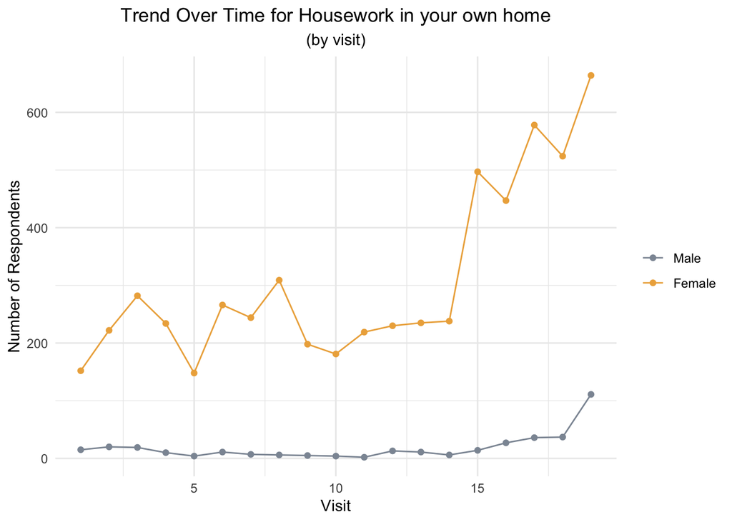

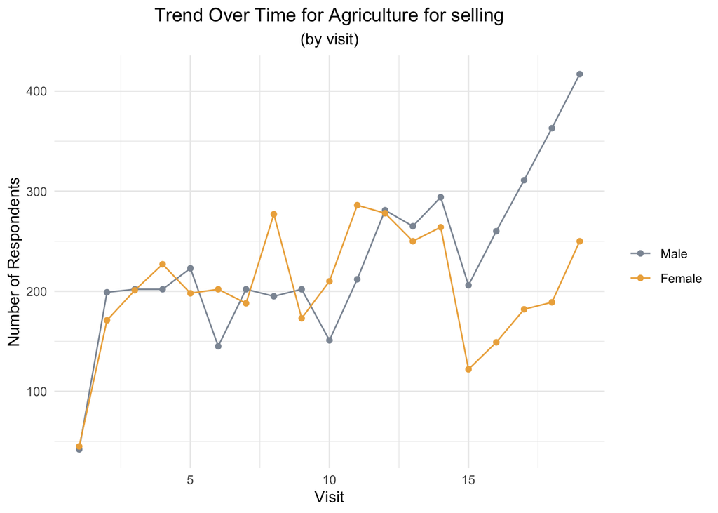

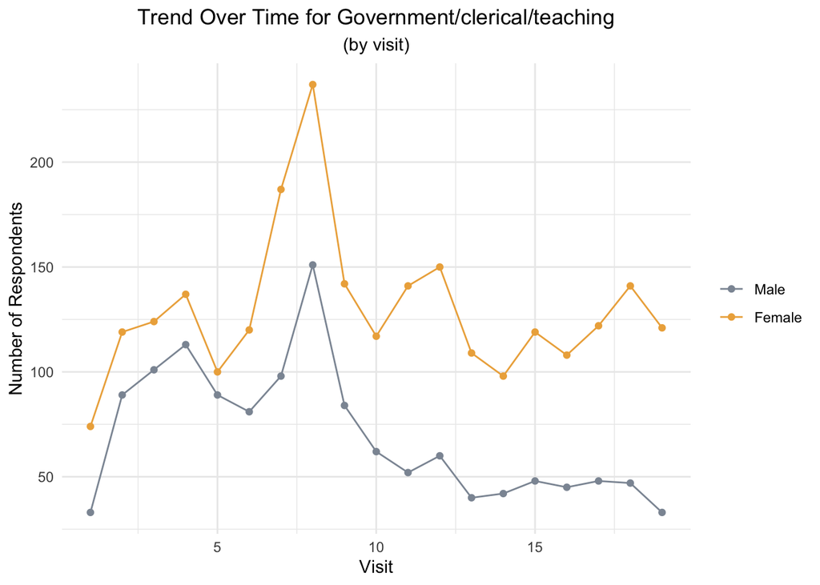

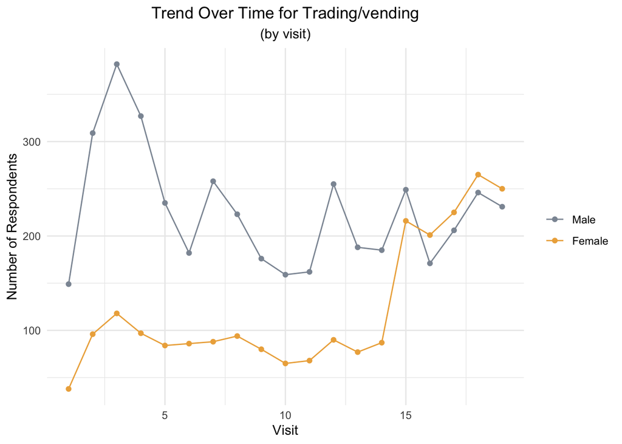

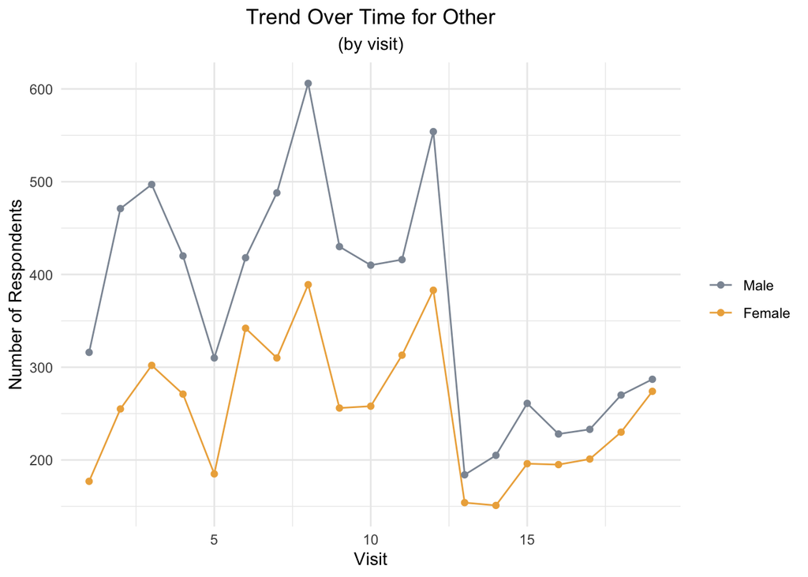

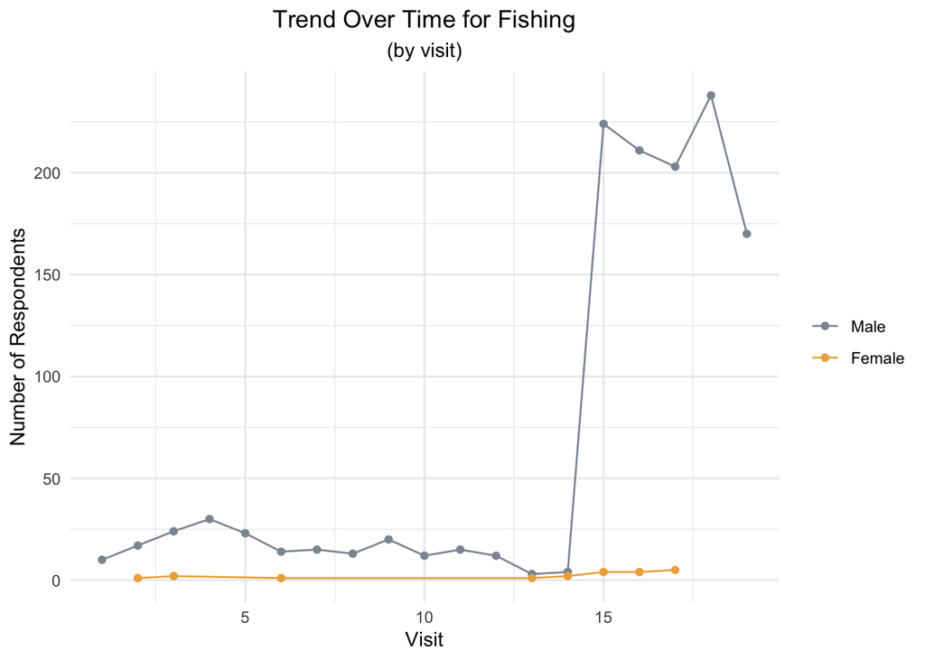

```r
occup_trend_visit <- dat_all %>%
  select(study_id, visit, area, female, age, age_cat, occup1, occup1_cat, occup1_mob) %>%
  filter(occup1 %in% c(1, 2, 3, 6, 7, 8, 11, 15)) %>%
  group_by(occup1, visit, female) %>%
  count(occup1) %>%
  as_factor()

for (i in occup_list){
  p <- occup_trend_visit %>%
    filter(occup1 == i) %>%
    drop_na(female) %>%
    ggplot(aes(x=visit, y=n, group=factor(female), color=factor(female))) +
    geom_line() + geom_point()+
    labs(x='Visit', y='Number of Respondents', title = paste("Trend Over Time for", i), subtitle = "(by visit)") +
    scale_color_manual(values = colors) +
    theme_minimal() + theme(plot.title = element_text(hjust = 0.5),
                            plot.subtitle = element_text(hjust = 0.5),
                            legend.title = element_blank())

  print(p)
}
```

- Trend by `age`

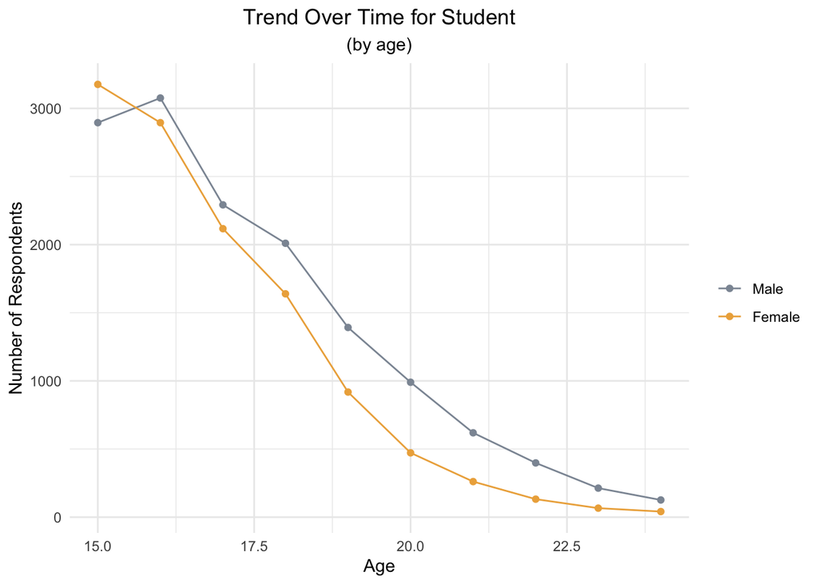

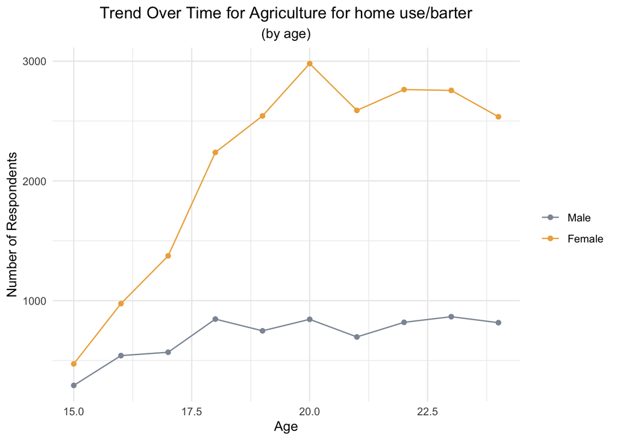

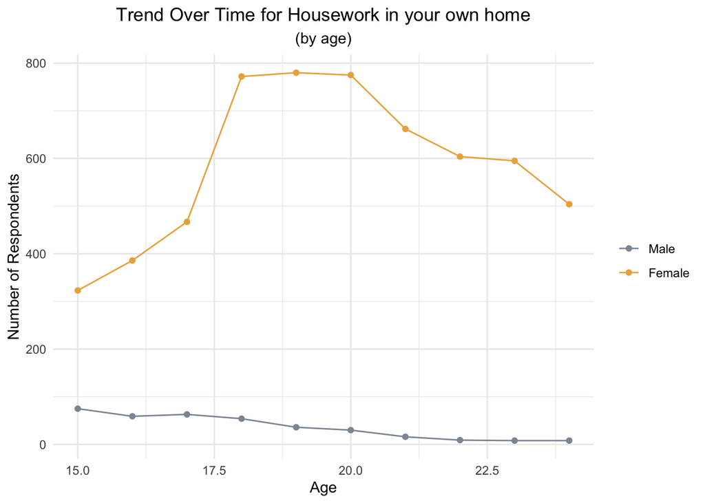

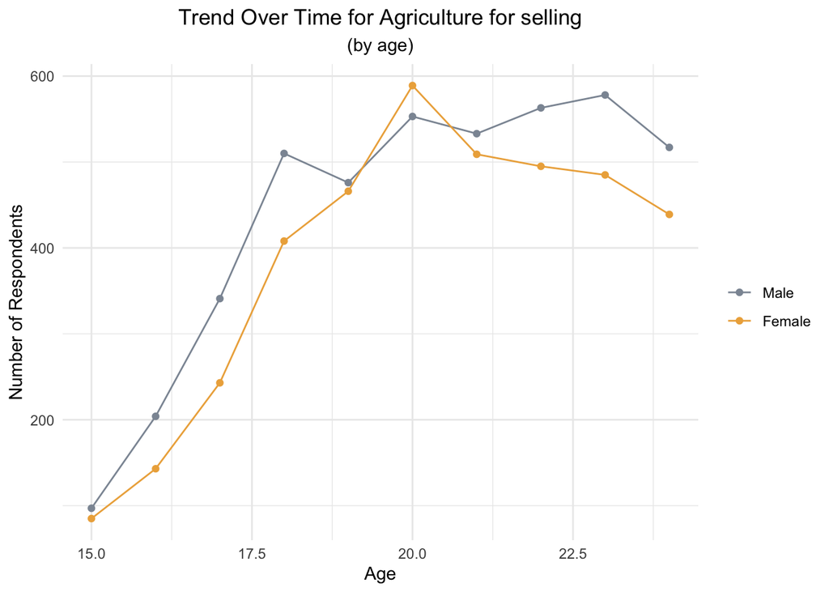

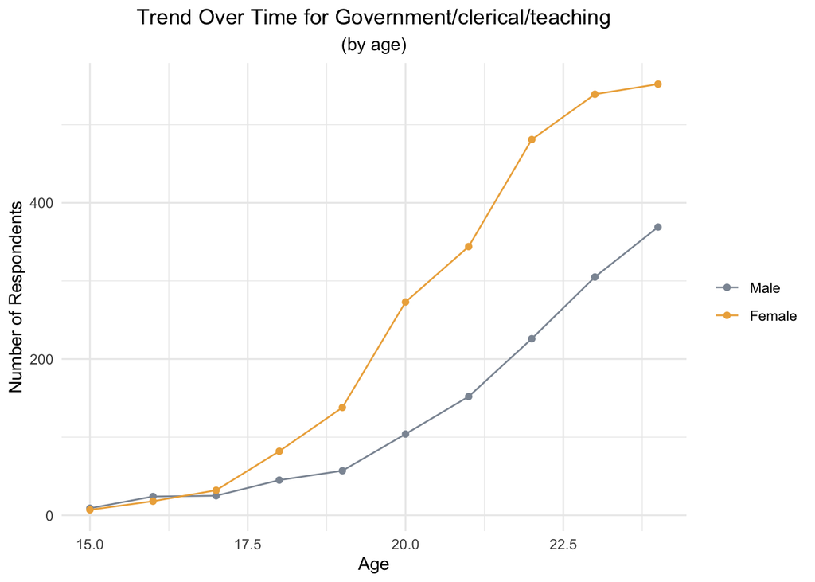

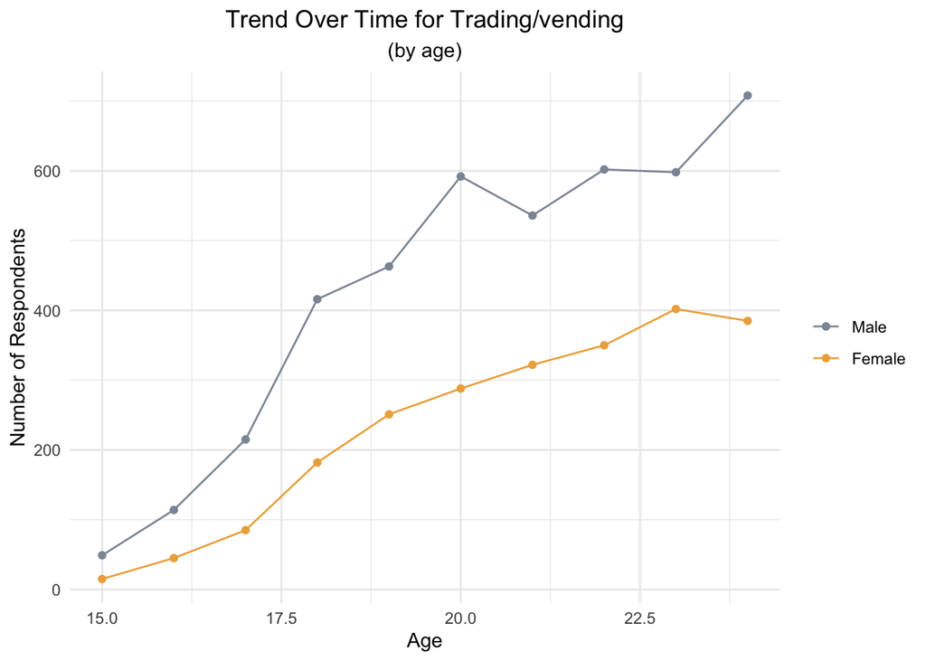

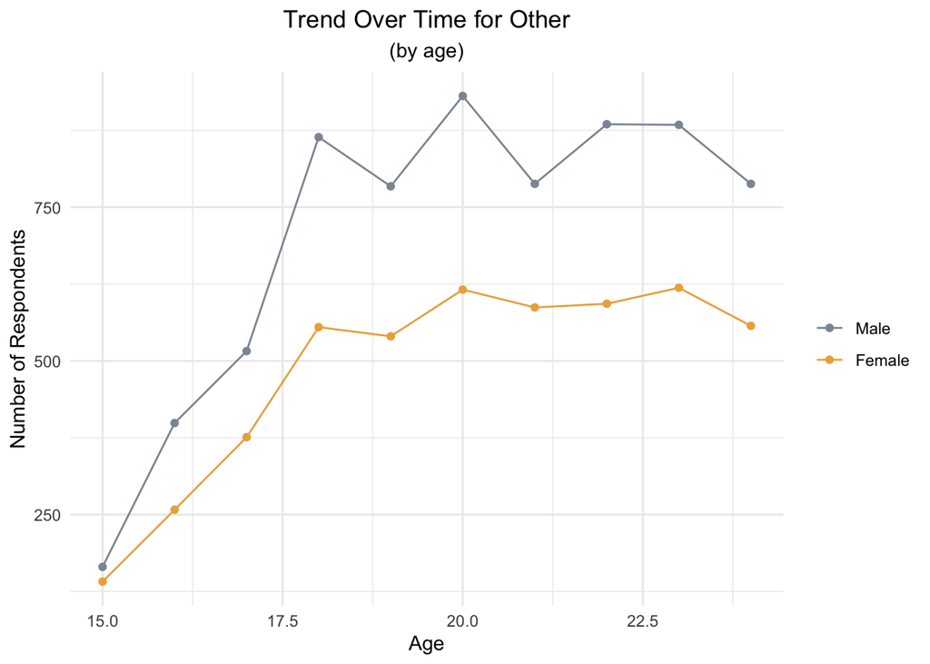

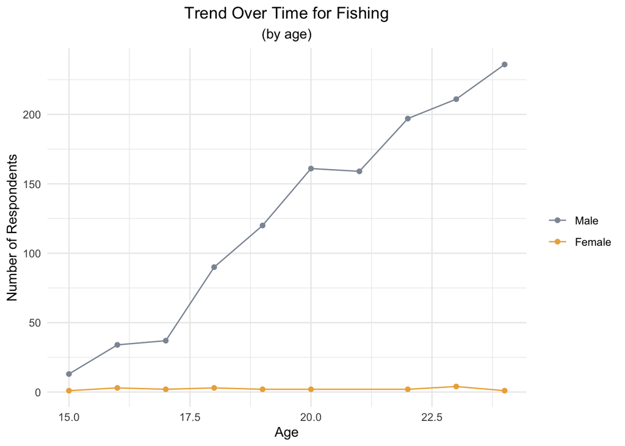

```r
occup_trend_age <- dat_all %>%
  select(study_id, visit, area, female, age, age_cat, occup1, occup1_cat, occup1_mob) %>%
  filter(occup1 %in% c(1, 2, 3, 6, 7, 8, 11, 15)) %>%
  group_by(occup1, age, female) %>%
  count(occup1) %>%
  as_factor()

for (i in occup_list){
  p <- occup_trend_age %>%
    filter(occup1 == i) %>%
    drop_na(female) %>%
    ggplot(aes(x=age, y=n, group=factor(female), color=factor(female))) +
    geom_line() + geom_point() +
    labs(x='Age', y='Number of Respondents', title=paste("Trend Over Time for", i), subtitle="(by age)") +
    scale_color_manual(values = colors) +
    theme_minimal() + theme(plot.title = element_text(hjust = 0.5),
                            plot.subtitle = element_text(hjust = 0.5),
                            legend.title = element_blank())

  print(p)
}
```

- Generate a word cloud for occupations described in `Other`

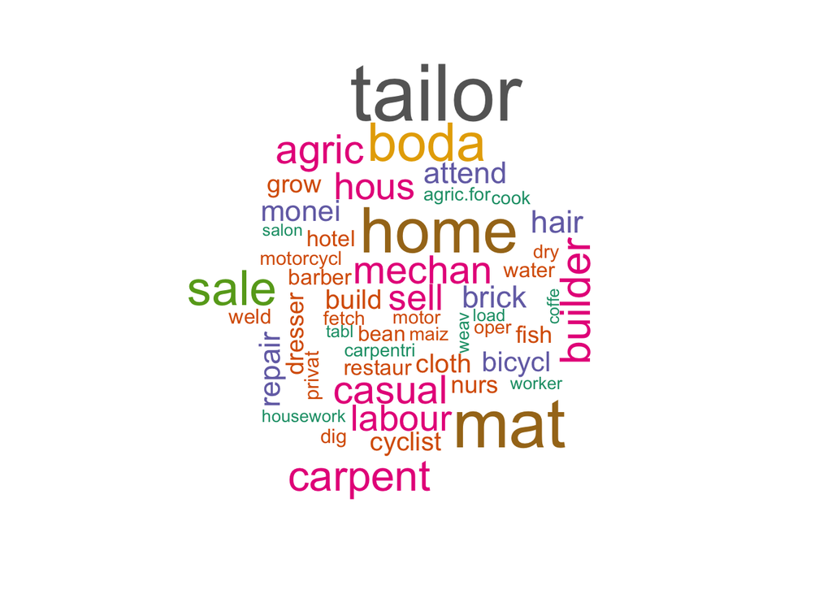

```r
library(tidytext)
library(wordcloud)
library(RColorBrewer)
library(SnowballC)

occs_word <-
  dat_all %>%
  select(occup1, occs) %>%
  filter(occup1 == 15, occs != "NULL") %>%
  unnest_tokens(word, occs) %>%
  mutate(word = wordStem(word)) %>%
  anti_join(stop_words) %>%
  count(word, sort = TRUE)

wordcloud(words = occs_word$word, freq = occs_word$n, max.words = 50, colors = brewer.pal(8, "Dark2"))
```

## Variable selection and transformation